# EDA-2D

Chidi

1/22/2018

### Covariation

While variation describes the behavior within a variable, covariation describes the behaviour between two variables. Covariation is the tendency of the values of two or more variables to vary together in a related way. The best way to spot covariation is to visualise variations between two or more variables.

```r
library(tidyverse)
library(nycflights13)
library(emo)
library(naniar)
library(ggstance)
library(lvplot)
library(patchwork)
```

#### A categorical and continuous variable

We may want to see the distribution of a continuous variable broken down by a categorical variable. We may want to use a normal `freqpoly`, but this wouldn’t be very useful for this comparison, because the height of the lines are given by the count, hence if one group is much smaller than the others, it’ll be hard to see the differences in the shape. For example;

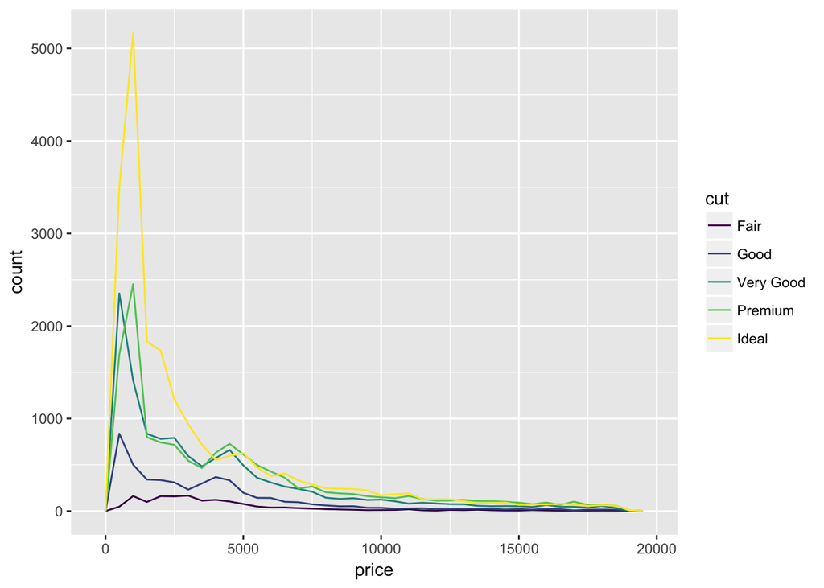

```r
ggplot(diamonds, aes(price)) +
  geom_freqpoly(aes(colour = cut), binwidth = 500)
```

In the above, its hard to see the difference in distribution because the counts vary very well. To make the comparison better, given that our goal is to compare different distributions across categories, what we can do is to have the y-axis shown as the *density*, which is the count standardised so that the area under each frequency polygon is 1

```r
diamonds %>%
  group_by(cut) %>%
  summarise(prices = median(price, na.rm = T))
```

```
#> # A tibble: 5 x 2
#>   cut       prices
#>   <ord>      <dbl>
#> 1 Fair        3282
#> 2 Good        3050
#> 3 Very Good   2648
#> 4 Premium     3185
#> 5 Ideal       1810
```

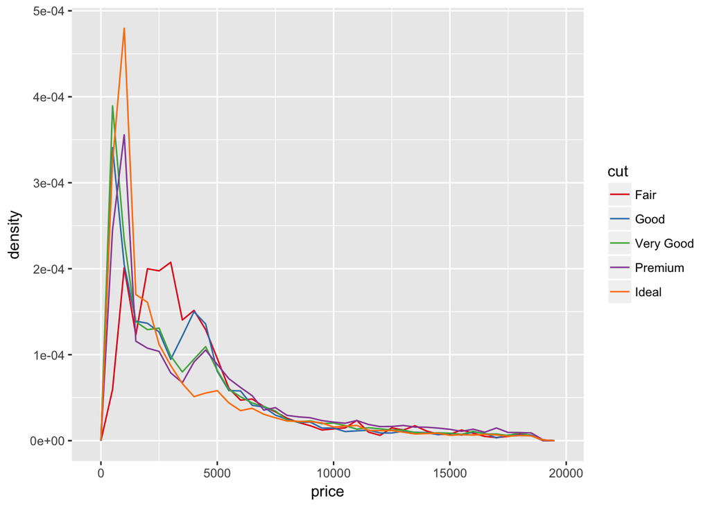

```r
ggplot(diamonds, aes(price, y = ..density..)) +
  geom_freqpoly(aes(colour = cut), binwidth = 500) +
  scale_colour_brewer(palette="Set1")
```

With the above plot, I can see and compare the distributions across the different categories, and intepret them. Like from the above plot, I can see that fair diamonds (low quality) has the highest average price. **Boxplots** are another alternative to display a continuous variable broken down by a categorical variable. A boxplot stretches from the 25<sup>th</sup> percentile to the 75<sup>th</sup> percentile, a range known as the Interquantile range (IQR). The middle of the box is a line showing the median (50<sup>th</sup> percentile). Points are plotted outside the boxplot edges, these are points that fall over 1.5 times from either edges of the IQR (i.e over 1.5 times below the 25<sup>th</sup> percentile, and/or over 1.5 times outside the 75<sup>th</sup> percentile). These points are seen as unusual (outliers), hence why they’re plotted individually.

So to make a boxplot of the distribution of price for each cut category

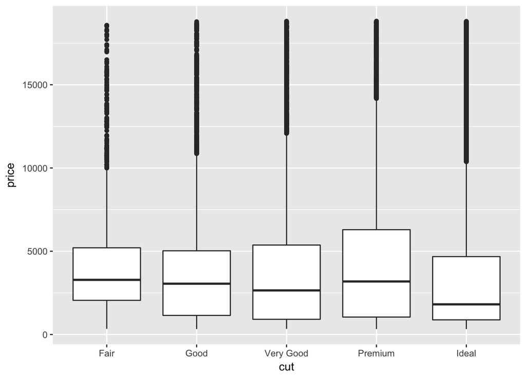

```r
ggplot(diamonds, aes(cut, price)) +
  geom_boxplot()
```

Looking at the plot above, and comparing with that of the freqpoly plot earlier, with this one, I also see that a better quality diamond are cheaper on average than fair diamonds (lowest qualiity) 🤔🤔🤔

The levels used by cut has an intrinsic ordering (good, very good, fair, etc), and we can use `reorder` function to reorder the boxplot. And the cut factor already had its levels ordered in an order I like;

```r
levels(diamonds$cut) # I can reorder this using reorder
```

```
#> [1] "Fair"      "Good"      "Very Good" "Premium"   "Ideal"
```

### 7.5.1.1 Exercises

##### 1. Use what you’ve learned to improve the visualisation of the departure times of cancelled vs. non-cancelled flights.

I can’t plot ggplot values in a ggplot2 plot, and so, to visualise this, I know that when `dep_time` is NA, it means the flight was cancelled, but there’s usually a scheduled time, so I can use that to know flights whose departure time is missing.

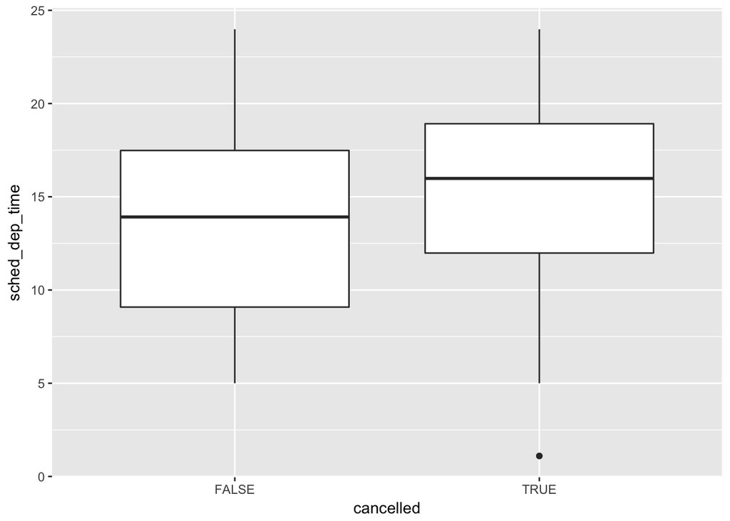

```r
flights_sched <- flights %>%
  select(dep_time, sched_dep_time) %>%
  mutate(cancelled = is.na(dep_time),
         sched_hours = sched_dep_time %/% 100,
         sched_mins = sched_dep_time %% 100,
         sched_dep_time = sched_hours + sched_mins / 60)

ggplot(flights_sched, aes(cancelled, sched_dep_time)) +
  geom_boxplot()
```

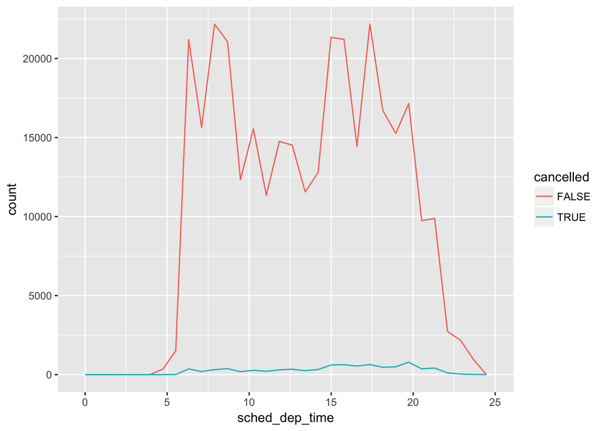

```r
ggplot(flights_sched, aes(sched_dep_time, colour = cancelled)) +
  geom_freqpoly()
```

I see that flights that’re cancelled usually have a late scheduled departure time. And there’re few cancelled flights cases.

##### 2. What variable in the diamonds dataset is most important for predicting the price of a diamond? How is that variable correlated with cut? Why does the combination of those two relationships lead to lower quality diamonds being more expensive?

To solve the first question, I’ll check which variable is most correlated with the `price` dataset, and I could also use regression as well.

```r
diamonds %>%
  select(carat, depth, table, price, x, y, z) %>%
  cor(.)
```

```
#>            carat       depth      table      price           x           y
#> carat 1.00000000  0.02822431  0.1816175  0.9215913  0.97509423  0.95172220
#> depth 0.02822431  1.00000000 -0.2957785 -0.0106474 -0.02528925 -0.02934067
#> table 0.18161755 -0.29577852  1.0000000  0.1271339  0.19534428  0.18376015
#> price 0.92159130 -0.01064740  0.1271339  1.0000000  0.88443516  0.86542090
#> x     0.97509423 -0.02528925  0.1953443  0.8844352  1.00000000  0.97470148
#> y     0.95172220 -0.02934067  0.1837601  0.8654209  0.97470148  1.00000000
#> z     0.95338738  0.09492388  0.1509287  0.8612494  0.97077180  0.95200572
#>                z
#> carat 0.95338738
#> depth 0.09492388
#> table 0.15092869
#> price 0.86124944
#> x     0.97077180
#> y     0.95200572
#> z     1.00000000
```

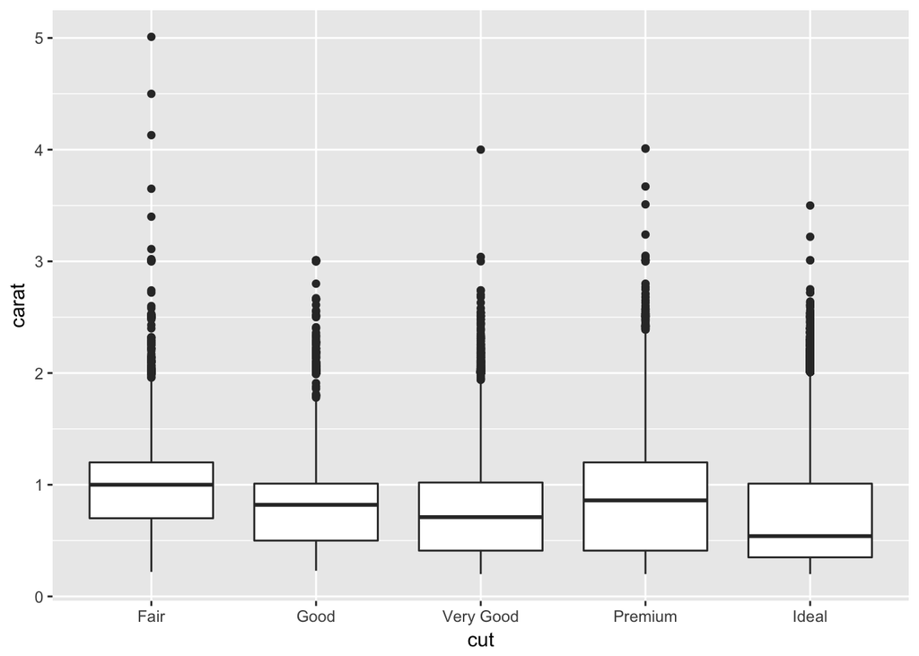

```r
ggplot(diamonds, aes(cut, carat)) +
  geom_boxplot()
```

From the above, I see that carat is a better price predictor.

##### 3.Install the ggstance package, and create a horizontal boxplot. How does this compare to using coord_flip()?

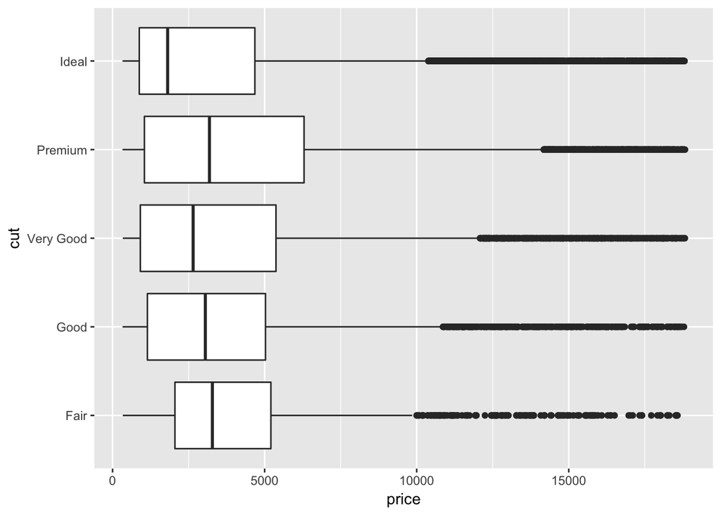

```r
ggplot(diamonds, aes(cut, price)) +
  geom_boxplot() +
  coord_flip()
```

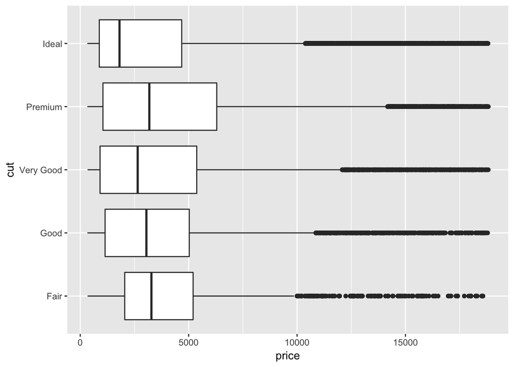

```r
ggplot(diamonds, aes(price, cut)) +
  geom_boxploth()
```

`ggstance` automatically applies a coord_flip action on a ggplot2 plot

##### 4. One problem with boxplots is that they were developed in an era of much smaller datasets and tend to display a prohibitively large number of “outlying values”. One approach to remedy this problem is the letter value plot. Install the lvplot package, and try using geom_lv() to display the distribution of price vs cut. What do you learn? How do you interpret the plots?

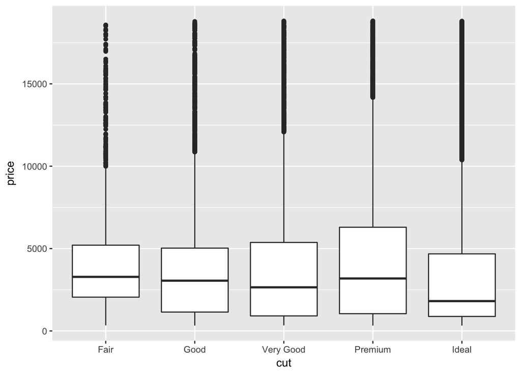

```r
ggplot(diamonds, aes(cut, price)) +
  geom_boxplot()
```

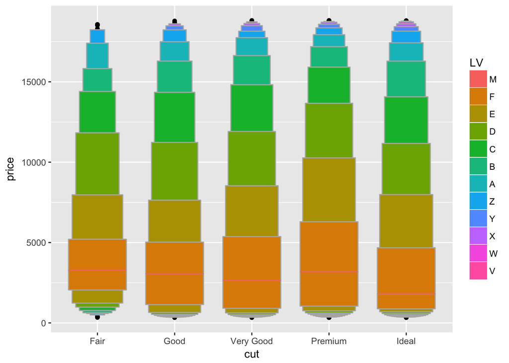

```r
ggplot(diamonds, aes(cut, price)) +
  geom_lv(aes(fill = ..LV..))
```

Basically, Letter-value plots are boxplots for large datasets, while normal boxplot is useful for showing small data sets (n < 200). When using a boxplot for large datasets (~ 10,000 - 100,000), the number of outliers grows linearly with the sample data (usually wrongly labelled as outlier in this case), also, the estimates of tail behaviour are not displayed, even though these large sample sizes means estimates on the tail are more likely to be genuine extreme observations, or true outliers as would be labelled by a boxplot. Letter-value plots are a variation of boxplots where the whiskers are replaced with a variable number of letter values, selected based on the number of observations. Any values outside the outermost letter value (note that each box above is coloured different by the letter it represents), is displayed individually and is what is considered outlier by this plot. These modifications reduce the amount of outliers we see in a boxplot for large datasets, and conveys more reliable information about the tails, and outliers are the most extreme values only. See the documentation for more info, or the paper [here](http://vita.had.co.nz/papers/letter-value-plot.pdf) (I’ll still have to look at it more)

##### 5. Compare and contrast geom_violin() with a facetted geom_histogram(), or a coloured geom_freqpoly(). What are the pros and cons of each method?

```
#> Warning in (function (..., na.rm = FALSE) : an argument will be
#> fractionally recycled
```

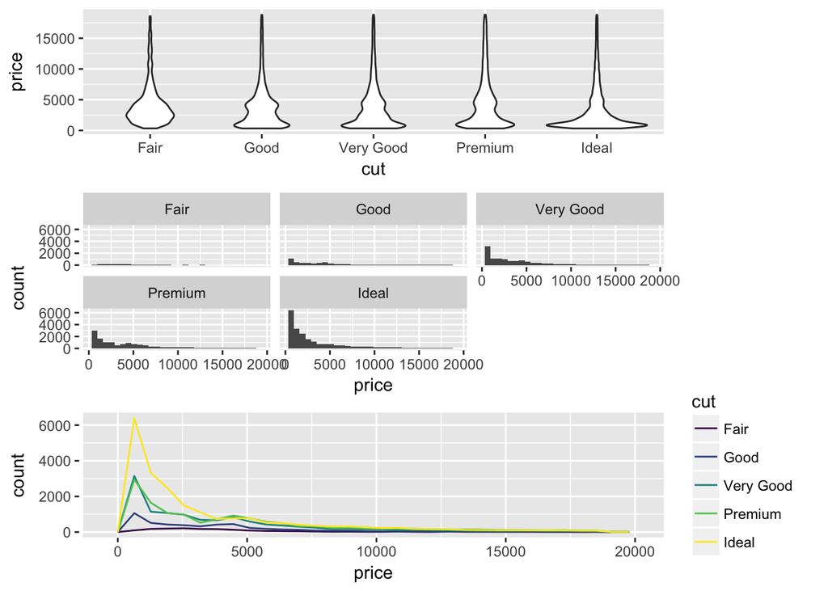

```r
ggplot(diamonds, aes(cut, price)) +
  geom_violin() +
ggplot(diamonds, aes(price)) +
  geom_histogram() +
  facet_wrap(~ cut) +
ggplot(diamonds, aes(price)) +
  geom_freqpoly(aes(color = cut)) +
plot_layout(ncol = 1)
```